DS 6030 | Fall 2024 | University of Virginia

# Homework #4: Trees and Random Forest

Author

Kiana Dane

Published

October 1, 2024

This is an **independent assignment**. Do not discuss or work with classmates.

# Required R packages and Directories

```r
data_dir = 'https://mdporter.github.io/teaching/data/' # data directory
library(tidyverse)    # functions for data manipulation
library(ranger)       # fast random forest implementation
library(modeldata)    # for the ames housing data
```

# Problem 1: Tree splitting metrics for classification

Consider the Gini index, classification error, and entropy impurity measures in a simple classification setting with two classes.

Create a single plot that displays each of these quantities as a function of $p_m$, the estimated probability of an observation in node $m$ being from class 1. The x-axis should display $p_m$, ranging from 0 to 1, and the y-axis should display the value of the Gini index, classification error, and entropy.

**Solution**

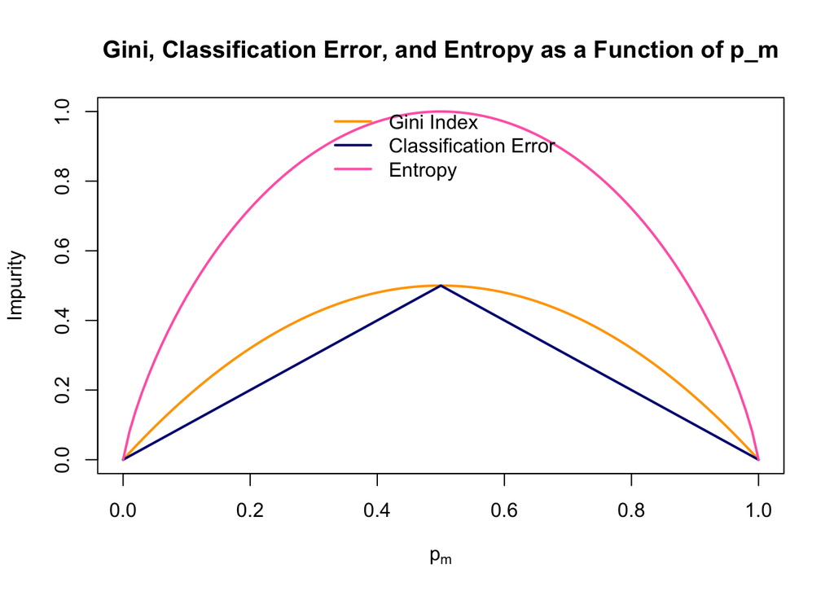

```r
p_m <- seq(0, 1, by = 0.01)

gini <- 2 * p_m * (1 - p_m)

class_error <- 1 - pmax(p_m, 1 - p_m)

entropy <- -(p_m * log2(p_m) + (1 - p_m) * log2(1 - p_m))

entropy[is.nan(entropy)] <- 0

plot(p_m, gini, type = "l", col = "orange", ylim = c(0, 1),
     xlab = expression(p[m]), ylab = "Impurity", lwd = 2,
     main = "Gini, Classification Error, and Entropy as a Function of p_m")

lines(p_m, class_error, col = "navy", lwd = 2)

lines(p_m, entropy, col = "hotpink", lwd = 2)

legend("top", legend = c("Gini Index", "Classification Error", "Entropy"),
       col = c("orange", "navy", "hotpink"), lwd = 2, bty = "n")
```

# Problem 2: Combining bootstrap estimates

## a. Majority Vote

ISLR 8.2 describies the *majority vote* approach for making a hard classification from a set of bagged classifiers. What is the final classification for this example using majority voting?

**Solution**

```r
prob_red = c(0.2, 0.25, 0.3, 0.4, 0.4, 0.45, 0.7, 0.85, 0.9, 0.9)

classifications <- ifelse(prob_red > 0.5, "Red", "Green")

final_majority_class <- ifelse(sum(classifications == "Red") > sum(classifications == "Green"), "Red", "Green")

cat("The final classification using average probability is:", final_majority_class, "\n")
```

```
The final classification using average probability is: Green
```

## b. Average Probability

An alternative is to base the final classification on the average probability. What is the final classification for this example using average probability?

**Solution**

```r
prob_red <- c(0.2, 0.25, 0.3, 0.4, 0.4, 0.45, 0.7, 0.85, 0.9, 0.9)

probs_string <- stringr::str_c(prob_red, collapse = ", ")

avg_prob <- mean(prob_red)

final_average_class <- ifelse(avg_prob > 0.5, "Red", "Green")

cat("The final classification using average probability is:", final_average_class, "\n")
```

```
The final classification using average probability is: Red
```

# Problem 3: Random Forest Tuning

Random forest has several tuning parameters that you will explore in this problem. We will use the `ames` housing data from the `modeldata` R package.

There are several R packages for Random Forest. The `ranger::ranger()` function is much faster than `randomForest::randomForest()` so we will use this one.

## a. Random forest (`ranger`) tuning parameters

List all of the random forest tuning parameters in the `ranger::ranger()` function. You don’t need to list the parameters related to computation, special models (e.g., survival, maxstat), or anything that won’t impact the predictive performance.

Indicate the tuning parameters you think will be most important to optimize?

**Solution**

```r
args(ranger::ranger)
```

```
function (formula = NULL, data = NULL, num.trees = 500, mtry = NULL,
    importance = "none", write.forest = TRUE, probability = FALSE,
    min.node.size = NULL, min.bucket = NULL, max.depth = NULL,
    replace = TRUE, sample.fraction = ifelse(replace, 1, 0.632),
    case.weights = NULL, class.weights = NULL, splitrule = NULL,
    num.random.splits = 1, alpha = 0.5, minprop = 0.1, split.select.weights = NULL,
    always.split.variables = NULL, respect.unordered.factors = NULL,
    scale.permutation.importance = FALSE, local.importance = FALSE,
    regularization.factor = 1, regularization.usedepth = FALSE,
    keep.inbag = FALSE, inbag = NULL, holdout = FALSE, quantreg = FALSE,
    time.interest = NULL, oob.error = TRUE, num.threads = NULL,
    save.memory = FALSE, verbose = TRUE, node.stats = FALSE,
    seed = NULL, dependent.variable.name = NULL, status.variable.name = NULL,
    classification = NULL, x = NULL, y = NULL, ...)
NULL
```

# Problem 3a

I think a few of the most important parameters to optimize will be num.trees, max.depth, importance, and min.node.size.

## b. Implement Random Forest

Use a random forest model to predict the sales price, `Sale_Price`. Use the default parameters and report the 10-fold cross-validation RMSE (square root of mean squared error).

**Solution**

```r
library(ranger)
library(caret)
library(modeldata)

data(ames)
ames <- as.data.frame(ames)
train_control <- trainControl(method = "cv", number = 10)

set.seed(123)

rf_model <- train(Sale_Price ~ .,
                  data = ames,
                  method = "ranger",
                  trControl = train_control,
                  importance = 'none')

print(rf_model)
```

```
Random Forest

2930 samples
  73 predictor

No pre-processing
Resampling: Cross-Validated (10 fold)
Summary of sample sizes: 2637, 2637, 2637, 2636, 2637, 2638, ...
Resampling results across tuning parameters:

  mtry  splitrule   RMSE   Rsquared  MAE
    2   variance    48128  0.791     31474
    2   extratrees  52822  0.739     35670
  139   variance    27438  0.884     16445
  139   extratrees  27609  0.886     16332
  276   variance    28300  0.876     16749
  276   extratrees  27365  0.886     16225

Tuning parameter 'min.node.size' was held constant at a value of 5
RMSE was used to select the optimal model using the smallest value.
The final values used for the model were mtry = 276, splitrule = extratrees
 and min.node.size = 5.
```

```r
rmse <- rf_model$results$RMSE
cat("The 10-fold cross-validation RMSE is:", rmse, "\n")
```

```
The 10-fold cross-validation RMSE is: 48128 52822 27438 27609 28300 27365
```

## c. Random Forest Tuning

Now we will vary the tuning parameters of `mtry` and `min.bucket` to see what effect they have on performance.

- Use a range of reasonable `mtry` and `min.bucket` values.
  - The valid `mtry` values are $\{1,2, \ldots, p\}$ where $p$ is the number of predictor variables. However the default value of `mtry = sqrt(p) =` 8 is usually close to optimal, so you may want to focus your search around those values.
  - The default `min.bucket=1` will grow deep trees. This will usually work best if there are enough trees. But try some values larger and see how it impacts predictive performance.
  - Set `num.trees=1000`, which is larger than the default of 500.
- Use 5 times repeated out-of-bag (OOB) to assess performance. That is, run random forest 5 times for each tuning set, calculate the OOB MSE each time and use the average for the MSE associated with the tuning parameters.
- Use a single plot to show the average MSE as a function of `mtry` and `min.bucket`.
- Report the best tuning parameter combination.
- Note: random forest is a stochastic model; it will be different every time it runs due to the bootstrap sampling and random selection of features to consider for splitting. Set the random seed to control the uncertainty associated with the stochasticity.
- Hint: If you use the `ranger` package, the `prediction.error` element in the output is the OOB MSE.

**Solution**

```r
library(ranger)
library(caret)
library(ggplot2)


data(ames, package = "modeldata")

ames <- as.data.frame(ames)

tuning_grid <- expand.grid(
  mtry = c(2, 5, 10, 50, 70),
  min.node.size = c(1, 5, 10, 20)
)

calculate_oob_mse <- function(mtry, min.node.size, num.trees = 1000, data, repetitions = 5) {
  mse_values <- numeric(repetitions)

  for (i in 1:repetitions) {
    set.seed(123 + i)

    model <- ranger(
      Sale_Price ~ .,
      data = data,
      mtry = mtry,
      min.node.size = min.node.size,
      num.trees = num.trees,
      importance = 'none',
      oob.error = TRUE
    )
    mse_values[i] <- model$prediction.error
  }

  return(mean(mse_values))
}

results <- expand.grid(mtry = tuning_grid$mtry, min.bucket = tuning_grid$min.node.size, MSE = NA)

for (i in 1:nrow(results)) {
  mtry <- results$mtry[i]
  min.bucket <- results$min.bucket[i]

  avg_mse <- calculate_oob_mse(mtry = mtry, min.node.size = min.bucket, data = ames)

  results$MSE[i] <- avg_mse
}

best_combination <- results[which.min(results$MSE), ]
cat("Best tuning parameters: mtry =", best_combination$mtry, "min.bucket =", best_combination$min.bucket, "\n")
```

```
Best tuning parameters: mtry = 10 min.bucket = 1
```

```r
cat("Best average MSE:", best_combination$MSE, "\n")
```

```
Best average MSE: 6.78e+08
```

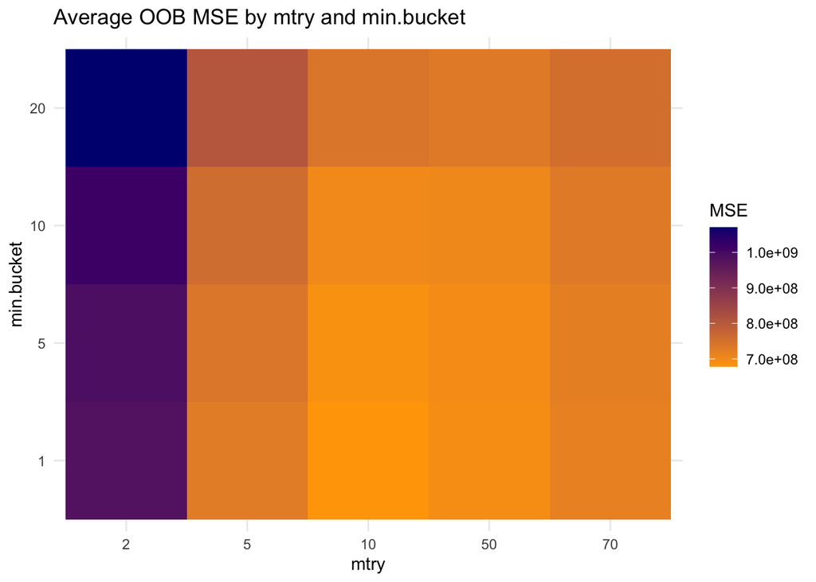

```r
ggplot(results, aes(x = factor(mtry), y = factor(min.bucket), fill = MSE)) +
  geom_tile() +
  scale_fill_gradient(low = "orange", high = "navy") +
  labs(title = "Average OOB MSE by mtry and min.bucket",
       x = "mtry",
       y = "min.bucket") +
  theme_minimal()
```